# Predictive Machine Learning Project

# Appendix 1: Course Project Submission of Test Cases

The second part of the assigment asks to make predictions for each of the 20 tests, write them to a file and submited. In the interest of completeness we have added the steps in this document, based on the instructions themselves[^3] and comments in the course discussion forum (as well as individual exploration, of course).

```r
## Use the original testing set
prediction <- predict(rf_model, pml_testing)
## Convert to char vector
prediction <- as.character(prediction)
## Function that writes to single files (from the instructions)
pml_write_files = function(x){
  n = length(x)
  for(i in 1:n){
    filename = paste0("problem_id_",i,".txt")
    write.table(x[i],file=filename,quote=FALSE,row.names=FALSE,col.names=FALSE)
  }
}
## Write files
pml_write_files(prediction)
```

This should result in individual files ready to be submitted.

# Appendix 2: An alternative model

As a complement to the main model we have added one additional approach which was attempted in the process but discarded in the early stages in favour or using Random Forests; this model uses regressive partitioning instead and can be useful to show the differences in model selection.

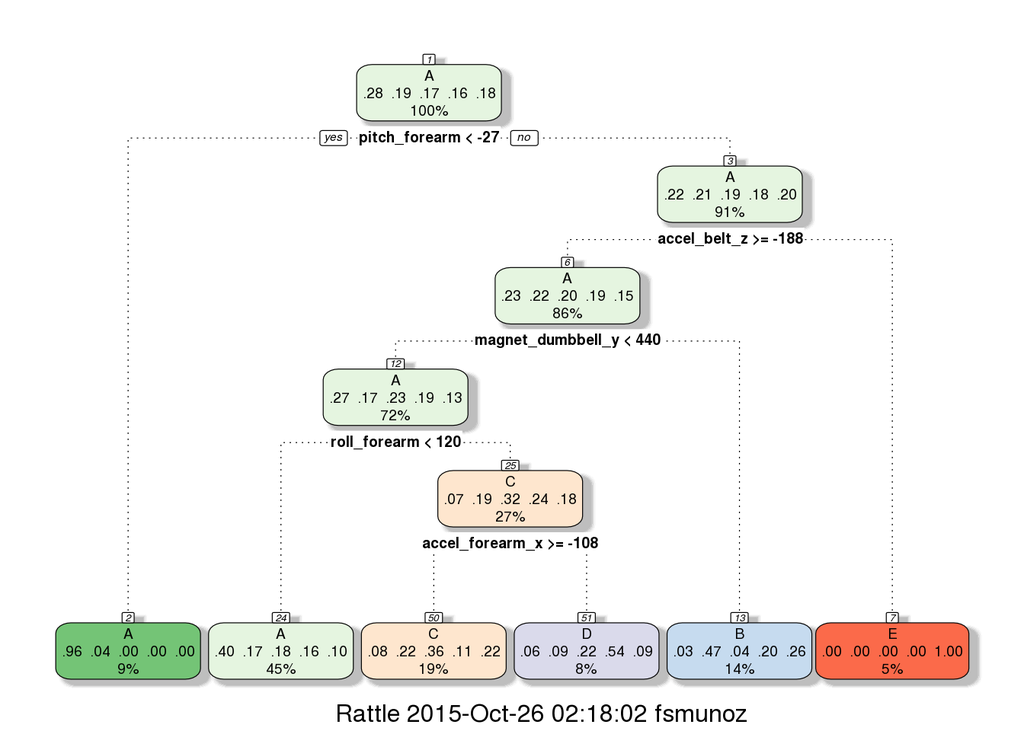

```r
rp_model = train(classe ~ ., method="rpart", data=training_set)
fancyRpartPlot(rp_model$finalModel)
```

This model has a much lower accuracy – below 50% actually.

```r
prediction <- predict(rp_model, testing_set)
mean(prediction == testing_set$class) * 100
```

```
## [1] 48.38134
```

The confusion matrix clearly confirms this lack of accuracy.

```r
confusionMatrix(testing_set$classe, prediction)
```

```
## Confusion Matrix and Statistics
##
##           Reference
## Prediction    A    B    C    D    E
##          A 2019   31  138   40    4
##          B  647  507  318   46    0
##          C  613   49  566  140    0
##          D  570  235  186  295    0
##          E  325  285  346   77  409
##
## Overall Statistics
##
##                Accuracy : 0.4838
##                  95% CI : (0.4727, 0.4949)
##     No Information Rate : 0.532
##     P-Value [Acc > NIR] : 1
##
##                   Kappa : 0.3249
##  Mcnemar's Test P-Value : <2e-16
##
## Statistics by Class:
##
##                      Class: A Class: B Class: C Class: D Class: E
## Sensitivity            0.4837  0.45799  0.36422  0.49331  0.99031
## Specificity            0.9420  0.84998  0.87254  0.86327  0.86103
## Pos Pred Value         0.9046  0.33399  0.41374  0.22939  0.28363
## Neg Pred Value         0.6161  0.90518  0.84748  0.95381  0.99938
## Prevalence             0.5320  0.14109  0.19806  0.07622  0.05264
## Detection Rate         0.2573  0.06462  0.07214  0.03760  0.05213
## Detection Prevalence   0.2845  0.19347  0.17436  0.16391  0.18379
## Balanced Accuracy      0.7129  0.65399  0.61838  0.67829  0.92567
```

References

Ugulino, Wallace, Débora Cardador, Katia Vega, Eduardo Velloso, Ruy Milidiú, and Hugo Fuks. 2012. “Wearable Computing: Accelerometers’ Data Classification of Body Postures and Movements.” In *Advances in Artificial Intelligence-SBIA 2012*, 52–61. Springer.

[^1]: This step is based on several contributions in the course forum
[^2]: And saved, again using a technic debated in the course forum and that avoid redoing the (expensive) calculation every time
[^3]: cf. https://class.coursera.org/predmachlearn-033/assignment/view?assignment_id=5